# MSIS 2506 R Project 2 Fall 2019

# Data Exploration

We will explore the data considering some feature individually and some in combination with each other to get a better sense of how these features affect our target variable.

### Univariate Visualization

#### Age

The dataset includes patients from age 28 to 77 years. The graph below shows a normal distribution of age, with around 60% population between the age of 45 and 65.

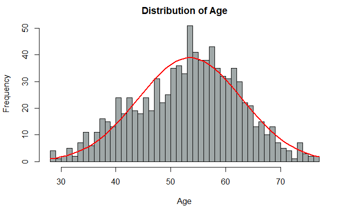

```r
x = data$age
h = hist(x, breaks = 50, col="#a0a8a8", xlab = "Age", main = "Distribution of Age")
xfit = seq(min(x), max(x), length = 50)
yfit = dnorm(xfit, mean = mean(x), sd = sd(x))
yfit = yfit*diff(h$mids[1:2])*length(x)
lines(xfit, yfit, col = "red", lwd = 2)
```

While the overall graph is normally distributed, if we categorize the polulation by country, we notice that Hungary’s dataset has a very short right tail, which means it appears that for this dataset we do not have enough data from relatively old people from Hungary.

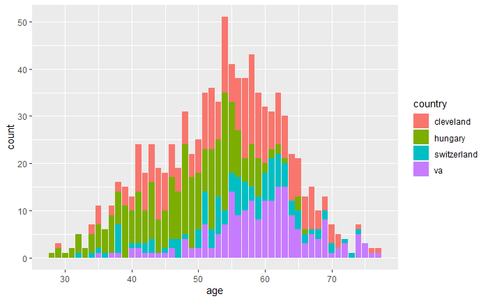

```r
ggplot(data = data)  + geom_bar(mapping = aes(x = age, fill = country ))
```

But how is age related to our target variable? And more specifically, what does each country tell us about the relationship between age and target variable? Let’s look at the plots given below. We see that there is an upward trend appearing that as patient’s age increases, it is more likely for them to get a heart related disease!

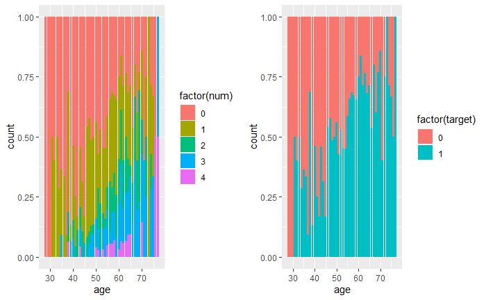

```r
g1 = ggplot(data = data)  + geom_bar(mapping = aes(x = age, fill = factor(num)), position = "fill")
g2 = ggplot(data = data)  + geom_bar(mapping = aes(x = age, fill = factor(target)), position = "fill")
grid.arrange(g1,g2, ncol=2)
```

If we look at the plots given below, we see that out of all the patients in Switzerland, surprisingly a majority of them suffer from a heart related disease. Based on this, we can hypothesize that either we do not have enough random samples, or because there is a large probability for Switzerland people to get heart disease. If we want to confirm our hypothesis and understand why the plot like this, we need more research and data.

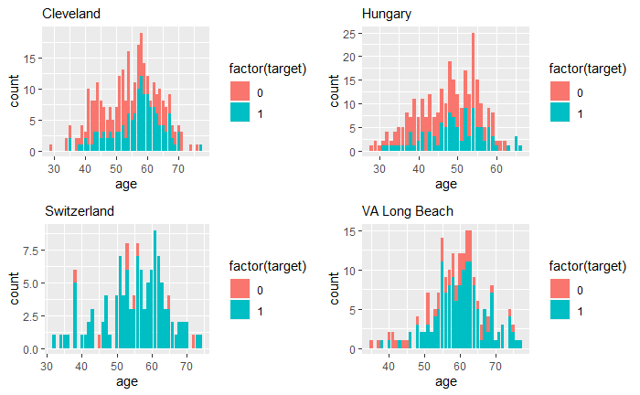

```r
Cleveland = subset(data, data$country == "cleveland")
Hungary = subset(data, data$country == "hungary")
Switzerland = subset(data, data$country == "switzerland")
VA = subset(data, data$country == "va")
a = ggplot(data = Cleveland)  + geom_bar(mapping = aes(x = age, fill = factor(target))) + labs(subtitle = "Cleveland")
b = ggplot(data = Hungary)  + geom_bar(mapping = aes(x = age, fill = factor(target))) + labs(subtitle = "Hungary")
c = ggplot(data = Switzerland)  + geom_bar(mapping = aes(x = age, fill = factor(target))) + labs(subtitle = "Switzerland")
d = ggplot(data = VA)  + geom_bar(mapping = aes(x = age, fill = factor(target))) + labs(subtitle = "VA Long Beach")
grid.arrange(a,b,c,d, nrow=2,ncol=2)
```